# Probability Distributions, Precision, Repeatability, Reproducibility (Stability), and Comparisons

# Using Distributions

## Example 1: dairy cows (normal distribution)

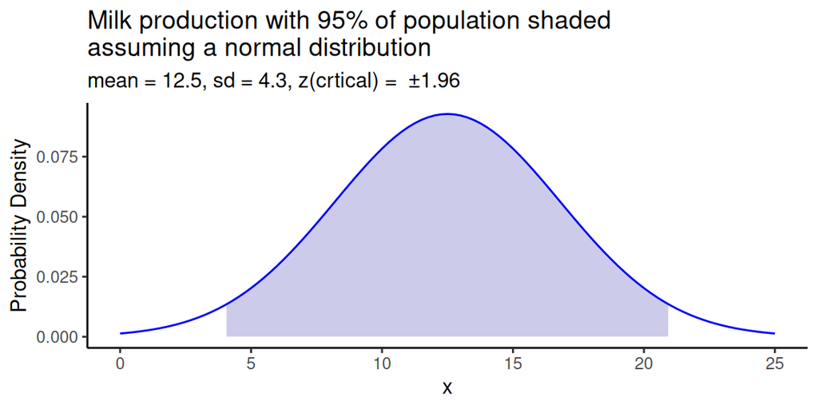

[Adapted from PSU Stats](https://online.stat.psu.edu/stat200/lesson/2/2.2/2.2.8)

A study of 66,831 dairy cows found the mean milk yield was 12.5 kg per milking with a standard deviation of 4.3 kg per milking.

**What range represents the 95% of the population?**

```r
# choose a level of alpha; 0.05 (need to divide by two for "two-tails")
qnorm(0.05/2)
```

```
[1] -1.959964
```

```r
qnorm(0.05/2, lower.tail = FALSE)
```

```
[1] 1.959964
```

```r
12.5 - 1.96*4.3
```

```
[1] 4.072
```

```r
12.5 + 1.96*4.3
```

```
[1] 20.928
```

## How did we create the graphic with `stat_fucntion()`

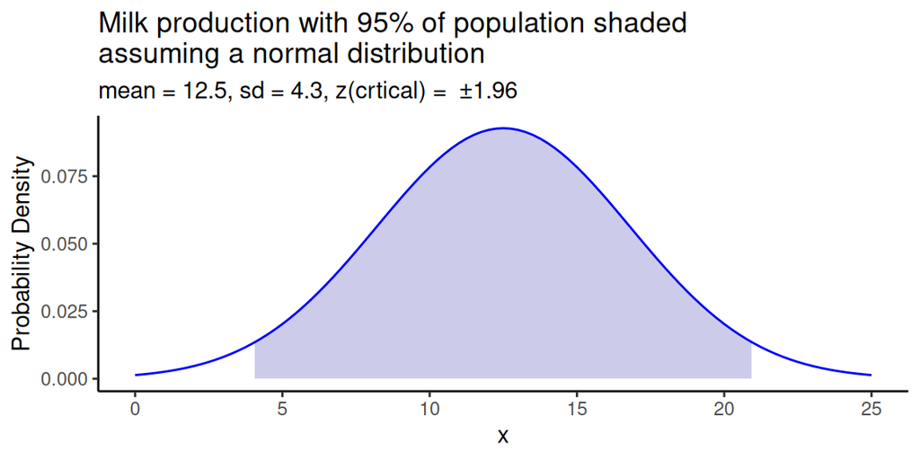

```r
tibble(x = c(0, 25)) |>
  ggplot() +
  stat_function(mapping = aes(x = x),
                fun = dnorm,
                args = list(mean = 12.5, sd = 4.3),
                color = "blue") +
  stat_function(mapping = aes(x = x),
                fun = dnorm,
                args = list(mean = 12.5, sd = 4.3),
                xlim = c(12.5 - 1.96*(4.3), 12.5 + 1.96*(4.3)),
                geom = "area",
                fill = "#000099", alpha = 0.2) +
  labs(
    title = "Milk production with 95% of population shaded \nassuming a normal distribution",
    subtitle = "mean = 12.5, sd = 4.3, z(crtical) =  ±1.96",
    y = "Probability Density"
  ) +
  theme_classic()
```

## Example 2: t distribution for smaller sample size

Instead of 66,831 dairy cows, we only had 6, but had the same descriptive statistics.

What would our probability distribution and 95% probability of data look like?

```r
qt(0.05/2, df = 5)
```

```
[1] -2.570582
```

```r
qt(0.05/2, df = 5, lower.tail = FALSE)
```

```
[1] 2.570582
```

```r
12.5 - 2.57*4.3
```

```
[1] 1.449
```

```r
12.5 + 2.57*4.3
```

```
[1] 23.551
```

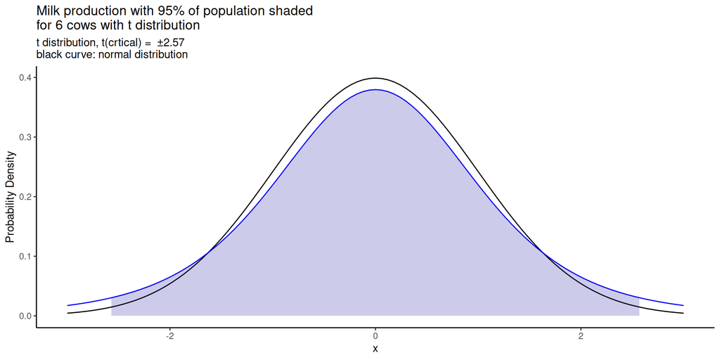

```r
tibble(x = c(-3, 3)) |>
  ggplot() +
  stat_function(mapping = aes(x = x),
                fun = dnorm,
                color = "black") +
  stat_function(mapping = aes(x = x),
                fun = dt,
                args = list(df = 5),
                color = "blue") +
  stat_function(mapping = aes(x = x),
                fun = dt,
                args = list(df = 5),
                xlim = c(-2.57, 2.57),
                geom = "area",
                fill = "#000099", alpha = 0.2) +
  labs(
    title = "Milk production with 95% of population shaded \nfor 6 cows with t distribution",
    subtitle = "t distribution, t(crtical) =  ±2.57 \nblack curve: normal distribution",
    y = "Probability Density"
  ) +
  theme_classic()
```

## Assignment

- Create plots for normal, t, and F distributions using ggplot’s `stat_function()` layer.
- Provide a brief description of each distribution and an example of how it is used. **Include descriptive titles, sub-titles, axis labels**
- For each distribution, provide the critical value(s) used to estimate 95% probability. (Only one example is needed if multiple distributions are possible.) Describe if you are using a “one-tailed” or “two-tailed” value.

# Accuracy, Bias, and Precision

## Accuracy and Bias

### Accuracy

Accuracy is a qualitative term referring to whether there is agreement between a measurement made on an object and its true (target or reference) value.

### Bias

Bias is a quantitative term describing the difference between the average of measurements made on the same object and its true value. In particular, for a measurement laboratory, bias is the difference (generally unknown) between a laboratory’s average value (over time) for a test item and the average that would be achieved by the reference laboratory if it undertook the same measurements on the same test item.

## Accuracy and Bias

## Accuracy and Precision

Low Accuracy  
Low Precision

Low Accuracy  
High Precision

High Accuracy  
Low Precision

High Accuracy  
High Precision

# Variability

## Variability, A Visual Comparison

What would this look like?

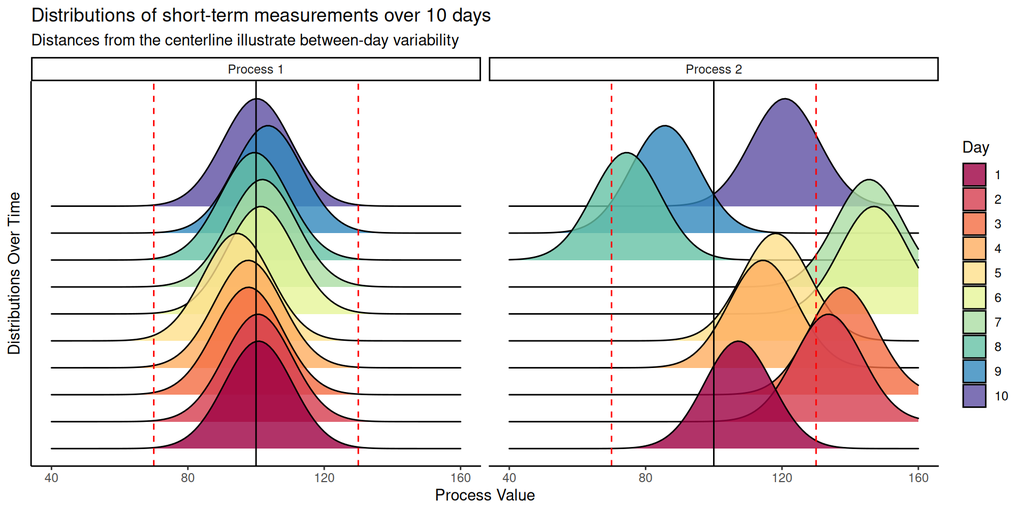

```r
set.seed(2020)

label_string <- as_labeller(c(process_1 = "Process 1", process_2 = "Process 2"))

my_dnorm_function <- function(x) {
  dnorm(seq(40, 160, 1), mean = x, sd = 10)
}

process_simulation <-  tibble(
  day = rep(1:10),
  process_1 = rnorm(10, mean = 100, sd = 2),
  process_2 = rnorm(10, mean = 120, sd = 15)
) |>
  pivot_longer(2:3, names_to = "mean_process", values_to = "mean_values") |>
  mutate(simulated_distribution = map(mean_values, my_dnorm_function)) |>
  unnest(cols = c(simulated_distribution)) |>
  mutate(x_values = rep(seq(40, 160, 1), times = 20))

process_simulation |>
  ggplot(aes(x = x_values, y = day, height = simulated_distribution*100, fill = as.factor(day))) +
  facet_wrap(vars(mean_process), labeller = label_string) +
  geom_ridgeline(alpha = 0.8) +
  geom_vline(xintercept = 100, color = "black") +
  geom_vline(xintercept = c(70, 130), color = "red", linetype = "dashed") +
  labs(
    x = "Process Value",
    y = "Distributions Over Time",
    fill = "Day",
    title = "Distributions of short-term measurements over 10 days",
    subtitle = "Distances from the centerline illustrate between-day variability"
  ) +
  guides(guides(fill = guide_legend(reverse = TRUE))) +
  scale_fill_brewer(palette = "Spectral") +
  theme_classic() +
  theme(axis.text.y = element_blank(), axis.ticks.y = element_blank())
```

## Terminology (NIST e-Handbook)

### Common terms to descrie short-term variability

1. precision
2. repeatability
3. within-time variability
4. short-term variability

### Common terms to describe long-term variability

1. day-to-day variability
2. long-term variability
3. reproducibility

## Recommendation: Adopt precise definitions

and, provide Best Known Methods (BKMs) or Standard Operating Procedures (SOPs) to ensure consistent implementation.

As an example, the NIST e-Handbook provides a [detailed description of the terms](https://www.itl.nist.gov/div898/handbook/mpc/section1/mpc114.htm)

- Level-1 standard deviation for short-term variability
- Level-2 standard deviation for day-to-day variability
- Level-3 standard deviation for long-term variability

## Short-term Variability: Precision

For $j$ measurements over $k$ days, the NIST e-Handbook defines the short-term variability as the standard deviation of the measurements:

$${\large s}_k = \sqrt{\frac{1}{J-1} \sum_{j=1}^{J} ( Y_{kj} - \overline{Y}_{k \, \small{\bullet}} ) ^2}$$

where:

$$\overline{Y}_{k \, \small{\bullet}} = \frac{1}{J}\sum_{j=1}^{J} Y_{kj}$$
is the mean of the $k$th day, and $Y_{kj}(k=1, \,\ldots, \, K, \,\, j=1, \,\ldots, \, J)$ are the individual measurements.

## Short-term Variability: Precision

### Data

```r
set.seed(42)

data_kj <- tibble(day_k = rep(1:5, each = 30),
              measurement_j = rnorm(150, mean = 100, sd = 3))
data_kj
```

| day_k | measurement_j |
| --- | --- |
| 1 | 104.11288 |
| 1 | 98.30591 |
| 1 | 101.08939 |
| 1 | 101.89859 |
| 1 | 101.21280 |
| 1 | 99.68163 |
| 1 | 104.53457 |
| 1 | 99.71602 |
| 1 | 106.05527 |
| 1 | 99.81186 |

[output cut: 140 more lines]

### Calculation

```r
level_1_kj = data_kj |>
  group_by(day_k) |>
  summarise(mean_k = mean(measurement_j),
            sd_k = sd(measurement_j))

level_1_kj
```

| day_k | mean_k | sd_k |
| --- | --- | --- |
| 1 | 100.20576 | 3.765084 |
| 2 | 99.63427 | 3.150169 |
| 3 | 100.57231 | 2.349712 |
| 4 | 99.94348 | 3.093249 |
| 5 | 99.21307 | 2.536934 |

## Simple Error Plot

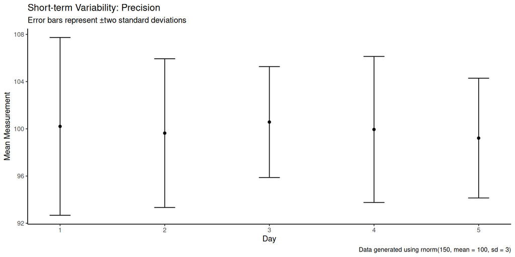

```r
level_1_kj |>
  ggplot(aes(x = day_k, y = mean_k, ymin = mean_k - 2*sd_k, ymax = mean_k + 2*sd_k)) +
  geom_point() +
  geom_errorbar(width = 0.2) +
  labs(
    x = "Day",
    y = "Mean Measurement",
    title = "Short-term Variability: Precision",
    subtitle = "Error bars represent \U00B1two standard deviations",
#    subtitle = TeX(r"(\textrm{Error bars represent }$\pm$\textrm{two standard deviations})"),
    caption = "Data generated using rnorm(150, mean = 100, sd = 3)"
  ) +
  theme_classic()
```

## Dataset 2

```r
set.seed(42)

data_2_kj <- tibble(day_k = rep(1:30, each = 30),
              measurement_j = rnorm(900, mean = 100, sd = 3))
data_2_kj
```

| day_k | measurement_j |
| --- | --- |
| 1 | 104.11288 |
| 1 | 98.30591 |
| 1 | 101.08939 |
| 1 | 101.89859 |
| 1 | 101.21280 |
| 1 | 99.68163 |
| 1 | 104.53457 |
| 1 | 99.71602 |
| 1 | 106.05527 |
| 1 | 99.81186 |

[output cut: 890 more lines]

### Grouping and Calculation

```r
level_1_2_kj = data_2_kj |>
  group_by(day_k) |>
  summarise(mean_k = mean(measurement_j),
            sd_k = sd(measurement_j))

level_1_2_kj
```

| day_k | mean_k | sd_k |
| --- | --- | --- |
| 1 | 100.20576 | 3.765084 |
| 2 | 99.63427 | 3.150169 |
| 3 | 100.57231 | 2.349712 |
| 4 | 99.94348 | 3.093249 |
| 5 | 99.21307 | 2.536934 |
| 6 | 99.94954 | 2.733782 |
| 7 | 99.57638 | 2.985436 |
| 8 | 99.97841 | 2.465849 |
| 9 | 99.96522 | 3.286972 |
| 10 | 100.30819 | 3.184180 |

[output cut: 20 more lines]

## Simple Error Plot of Dataset 2

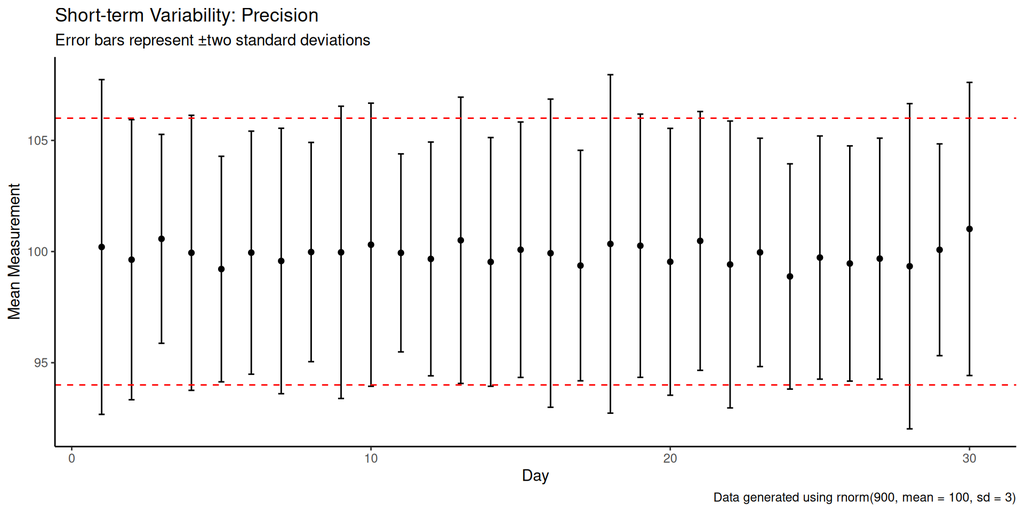

```r
level_1_2_kj |>
  ggplot(aes(x = day_k, y = mean_k, ymin = mean_k - 2*sd_k, ymax = mean_k + 2*sd_k)) +
  geom_point() +
  geom_errorbar(width = 0.2) +
  geom_hline(yintercept = c(94, 106), color = "red", linetype = "dashed") +
  labs(
    x = "Day",
    y = "Mean Measurement",
    title = "Short-term Variability: Precision",
    subtitle = "Error bars represent \U00B1two standard deviations",
#    subtitle = TeX(r"(\textrm{Error bars represent }$\pm$\textrm{two standard deviations})"),
    caption = "Data generated using rnorm(900, mean = 100, sd = 3)"
  ) +
  theme_classic()
```

Level-2 Standard Deviation

$${\large s}_2 = \sqrt{\frac{1}{K-1} \sum_{k=1}^{K} \left( \overline{Y}_{k \, \small{\bullet}} - \overline{Y}_{\small{\bullet} \small{\bullet}} \right) ^2}$$

where:

$$\overline{Y}_{\small{\bullet} \small{\bullet}} = \frac{1}{K} \sum_{k=1}^{K} \overline{Y}_{k \, \small{\bullet}}$$

is the grand mean of all measurements, and $\overline{Y}_{k \, \small{\bullet}}$ is the mean of the $k$th day.